# Predicción de la pobreza en Colombia - Taller 2 BDML

### 2.3.1 📊 CURVA ROC Y AUC

```r
roc_elastic_ext <- roc(response = as.numeric(test_modelo_ext$pobre),
                       predictor = test_modelo_ext$prob_pred,
                       levels = c(0,1))

auc(roc_elastic_ext)
```

```
## Area under the curve: 1
```

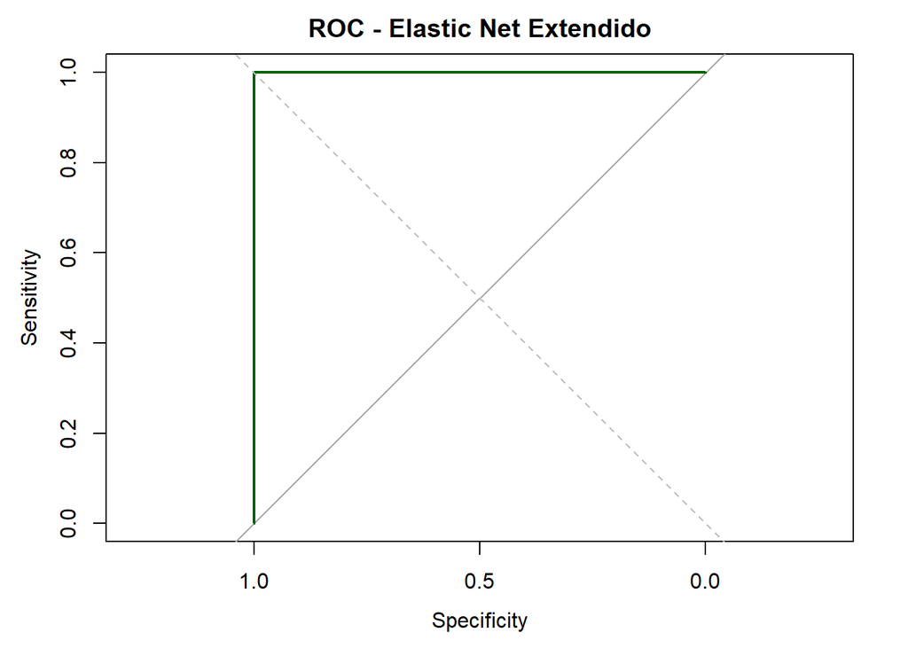

```r
plot(roc_elastic_ext, col = "darkgreen", lwd = 2, main = "ROC - Elastic Net Extendido")
abline(a = 0, b = 1, lty = 2, col = "gray")
```

### 2.3.2 💾 GUARDAR PREDICCIONES EN CSV

```r
predicciones_ext <- test_modelo_ext %>% select(id, pobre)
write_csv(predicciones_ext, "predicciones_elastic_net_extendido.csv")
```

## 2.4 3.2 Árboles de Clasificación (CART)

Los árboles de decisión tipo CART (Classification and Regression Trees) son modelos de clasificación que permiten segmentar los datos a través de reglas de decisión simples. Una de sus principales ventajas es su **interpretabilidad**, ya que permiten visualizar el proceso de clasificación de manera jerárquica. En este caso, utilizamos CART para predecir la condición de pobreza del hogar. A continuación se presenta la implementación completa:

Se cargan las librerías necesarias: - `caret`: para entrenamiento y validación cruzada. - `rpart`: para construir árboles de clasificación. - `rpart.plot`: para visualizar los árboles de decisión. - `MLmetrics`: para calcular métricas como el F1 Score.

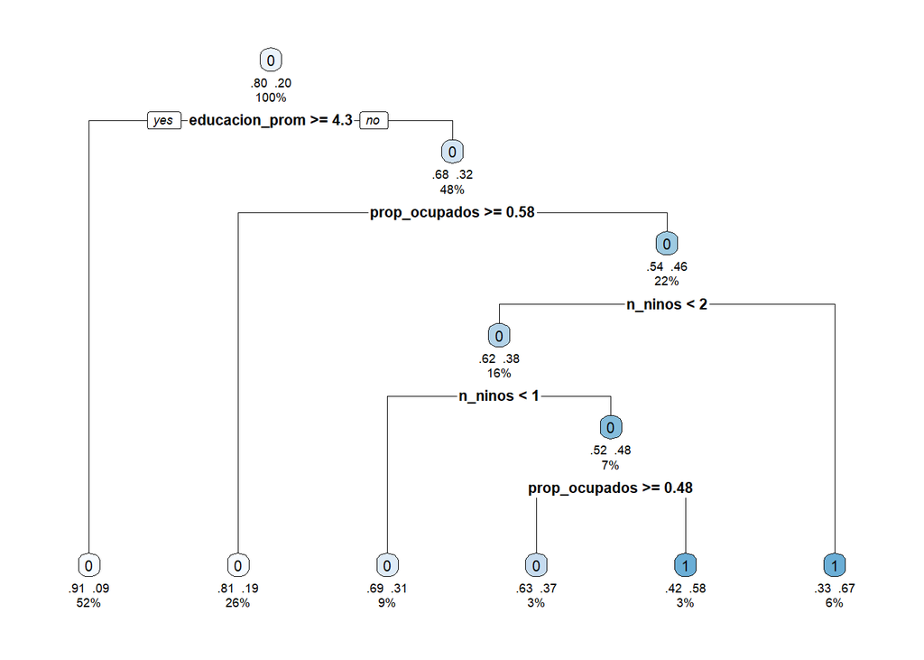

```r
# Cargar librerías necesarias
p_load(caret,
       rpart,
       rpart.plot,
       MLmetrics)


# Entrenamiento inicial del CART básico
modelo_cart <- rpart(
  formula = pobre ~ .,
  data = vars_modelo_ext,
  method = "class",
  parms = list(split = "gini"),
  control = rpart.control(cp = 0.01, minsplit = 20)
)

# Visualización del árbol inicial
rpart.plot(
  modelo_cart,
  type = 2,
  extra = 104,
  under = TRUE,
  fallen.leaves = TRUE,
  box.palette = "Blues"
)
```

```r
# Evaluación del modelo
pred_entrenamiento <- predict(modelo_cart, newdata = vars_modelo_ext, type = "class")

f1_cart <- F1_Score(
  y_pred = as.character(pred_entrenamiento),
  y_true = as.character(vars_modelo_ext$pobre),
  positive = "1"
)

print(paste("F1 Score del CART en train:", round(f1_cart, 4)))
```

```
## [1] "F1 Score del CART en train: 0.4135"
```

```r
# Segundo intento: CART con tuning de hiperparámetros
set.seed(123)

ctrl <- trainControl(
  method = "cv",
  number = 5,
  summaryFunction = defaultSummary,
  classProbs = TRUE
)

grid <- expand.grid(cp = seq(0.0001, 0.05, by = 0.002))

vars_modelo_ext <- vars_modelo_ext %>%
  mutate(pobre = factor(pobre, levels = c(0, 1), labels = c("no", "si")))

modelo_cart_cv <- train(
  pobre ~ .,
  data = vars_modelo_ext,
  method = "rpart",
  trControl = ctrl,
  tuneGrid = grid,
  metric = "Accuracy"
)

print(modelo_cart_cv)
```

```
## CART
##
## 164960 samples
##     12 predictor
##      2 classes: 'no', 'si'
##
## No pre-processing
## Resampling: Cross-Validated (5 fold)
## Summary of sample sizes: 131968, 131969, 131967, 131968, 131968
## Resampling results across tuning parameters:
##
##   cp      Accuracy   Kappa
##   0.0001  0.8363179  0.3977631
##   0.0021  0.8311227  0.3364552
##   0.0041  0.8292495  0.3468465
##   0.0061  0.8258548  0.3249233
##   0.0081  0.8258548  0.3249233
##   0.0101  0.8258548  0.3249233
##   0.0121  0.8243635  0.3064985
##   0.0141  0.8221569  0.2743499
##   0.0161  0.8221569  0.2743499
##   0.0181  0.8221569  0.2743499
##   0.0201  0.8204171  0.2776762
##   0.0221  0.8189258  0.2827019
##   0.0241  0.8189258  0.2827019
##   0.0261  0.8189258  0.2827019
##   0.0281  0.8148217  0.2110162
##   0.0301  0.8148217  0.2110162
##   0.0321  0.8148217  0.2110162
##   0.0341  0.8118512  0.1454748
##   0.0361  0.7998060  0.0000000
##   0.0381  0.7998060  0.0000000
##   0.0401  0.7998060  0.0000000
##   0.0421  0.7998060  0.0000000
##   0.0441  0.7998060  0.0000000
##   0.0461  0.7998060  0.0000000
##   0.0481  0.7998060  0.0000000
##
## Accuracy was used to select the optimal model using the largest value.
## The final value used for the model was cp = 1e-04.
```

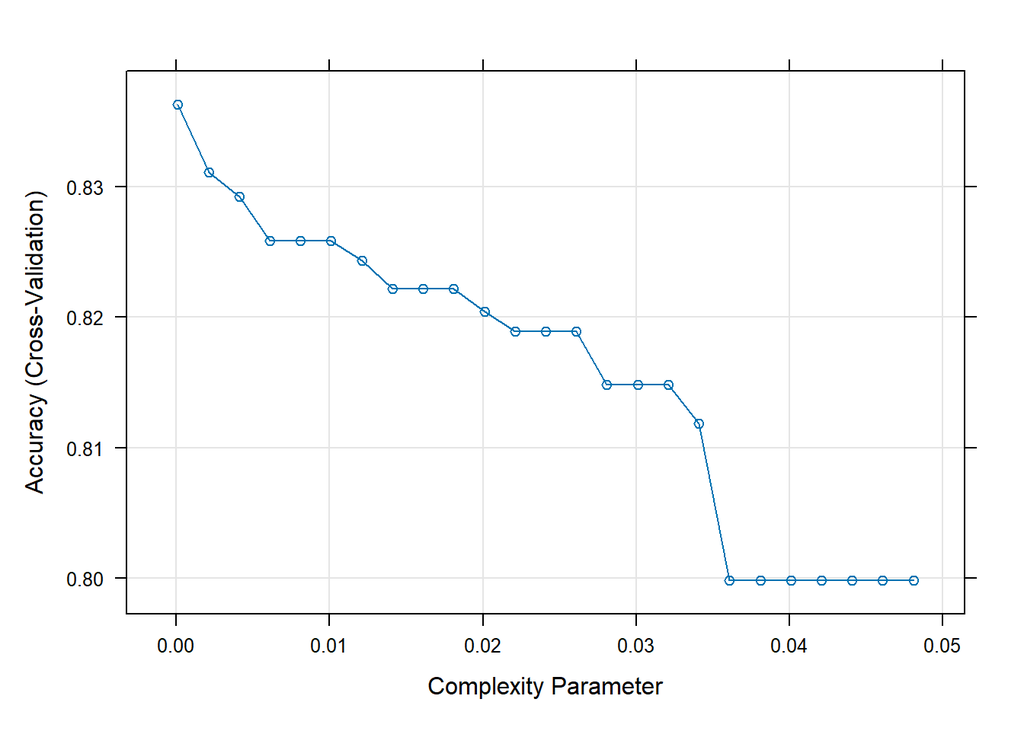

```r
plot(modelo_cart_cv)
```

[figure not shown]

```r
# Árbol final podado
rpart.plot(
  modelo_cart_cv$finalModel,
  type = 2,
  extra = 104,
  under = TRUE,
  fallen.leaves = TRUE,
  box.palette = "Blues"
)
```

```r
# Predicción y evaluación final
pred_entrenamiento <- predict(modelo_cart_cv, newdata = vars_modelo_ext)

f1_cart_cv <- F1_Score(
  y_pred = pred_entrenamiento,
  y_true = vars_modelo_ext$pobre,
  positive = "si"
)

print(paste("F1 Score del CART podado (train):", round(f1_cart_cv, 4)))
```

```
## [1] "F1 Score del CART podado (train): 0.5184"
```

```r
confusionMatrix(
  data = pred_entrenamiento,
  reference = vars_modelo_ext$pobre,
  mode = "everything",
  positive = "si"
)
```

```
## Confusion Matrix and Statistics
##
##           Reference
## Prediction     no     si
##         no 125786  19318
##         si   6150  13706
##
##                Accuracy : 0.8456
##                  95% CI : (0.8439, 0.8474)
##     No Information Rate : 0.7998
##     P-Value [Acc > NIR] : < 2.2e-16
##
##                   Kappa : 0.4332
##
##  Mcnemar's Test P-Value : < 2.2e-16
##
##             Sensitivity : 0.41503
##             Specificity : 0.95339
##          Pos Pred Value : 0.69027
##          Neg Pred Value : 0.86687
##               Precision : 0.69027
##                  Recall : 0.41503
##                      F1 : 0.51838
##              Prevalence : 0.20019
##          Detection Rate : 0.08309
##    Detection Prevalence : 0.12037
##       Balanced Accuracy : 0.68421
##
##        'Positive' Class : si
##
```

## 2.5 3.3 Ensamble de Logit y Random Forest

```r
# ─────────────────────────────────────────────────────────────
# 📦 CARGA DE PAQUETAS
# ─────────────────────────────────────────────────────────────
# 📦 Cargar librerías
library(tidyverse)
library(ranger)

# 🎯 Entrenamiento del modelo Random Forest
modelo_rf <- ranger(
  formula = pobre ~ .,
  data = vars_modelo_ext,
  probability = TRUE,
  num.trees = 100,
  mtry = 3,
  min.node.size = 20,
  class.weights = c("0" = 1, "1" = 3),
  seed = 123
)

# 🎯 Entrenamiento del modelo Logit
modelo_logit <- glm(pobre ~ ., data = vars_modelo_ext, family = binomial)

# 🔮 Predicción sobre el test (probabilidades)
probs_logit <- predict(modelo_logit, newdata = vars_test_ext, type = "response")
rf_pred <- predict(modelo_rf, data = vars_test_ext)$predictions
probs_rf <- if ("1" %in% colnames(rf_pred)) rf_pred[, "1"] else rf_pred[, 1]

# 🤝 Ensamble inicial de probabilidades (60% RF, 40% Logit)
prob_ensamble <- 0.6 * probs_rf + 0.4 * probs_logit
cutoff_final <- 0.33
preds <- ifelse(prob_ensamble > cutoff_final, 1, 0)

# 🎯 Preparación para validación cruzada del peso del ensamble
set.seed(123)
k <- 5
n <- nrow(vars_modelo_ext)
folds <- sample(rep(1:k, length.out = n))
rf_weights <- seq(0.1, 0.9, by = 0.1)
cutoff_ensamble <- 0.33
grid_results <- list()

# 🔁 Grid Search por el mejor peso
for (w in rf_weights) {
  logit_w <- 1 - w
  fold_metrics <- list()

  for (fold in 1:k) {
    train_fold <- vars_modelo_ext[folds != fold, ]
    val_fold   <- vars_modelo_ext[folds == fold, ]

    modelo_rf <- ranger(
      formula = pobre ~ .,
      data = train_fold,
      probability = TRUE,
      num.trees = 100,
      mtry = 3,
      min.node.size = 20,
      class.weights = c("0" = 1, "1" = 3),
      seed = 123
    )
    rf_val_pred <- predict(modelo_rf, data = val_fold)$predictions
    probs_rf <- if ("1" %in% colnames(rf_val_pred)) rf_val_pred[, "1"] else rf_val_pred[, 1]

    modelo_logit <- glm(pobre ~ ., data = train_fold, family = binomial)
    probs_logit <- predict(modelo_logit, newdata = val_fold, type = "response")

    prob_final <- w * probs_rf + logit_w * probs_logit
    pred <- ifelse(prob_final > cutoff_ensamble, 1, 0)
    real <- val_fold$pobre

    tp <- sum(pred == 1 & real == 1)
    tn <- sum(pred == 0 & real == 0)
    fp <- sum(pred == 1 & real == 0)
    fn <- sum(pred == 0 & real == 1)

    precision <- ifelse(tp + fp == 0, NA, tp / (tp + fp))
    recall <- ifelse(tp + fn == 0, NA, tp / (tp + fn))
    f1 <- ifelse(is.na(precision) | is.na(recall) | (precision + recall) == 0, NA,
                 2 * precision * recall / (precision + recall))

    fold_metrics[[fold]] <- tibble(fold, precision, recall, f1)
  }

  resumen <- bind_rows(fold_metrics) %>%
    summarise(across(precision:f1, mean, na.rm = TRUE)) %>%
    mutate(rf_weight = w, logit_weight = logit_w)

  grid_results[[length(grid_results) + 1]] <- resumen
}

# 📊 Tabla final ordenada por F1
pesos_optimos <- bind_rows(grid_results) %>% arrange(desc(f1))
print(pesos_optimos)
```

```
## # A tibble: 9 × 5
##   precision recall    f1 rf_weight logit_weight
##       <dbl>  <dbl> <dbl>     <dbl>        <dbl>
## 1       NaN    NaN   NaN       0.1          0.9
## 2       NaN    NaN   NaN       0.2          0.8
## 3       NaN    NaN   NaN       0.3          0.7
## 4       NaN    NaN   NaN       0.4          0.6
## 5       NaN    NaN   NaN       0.5          0.5
## 6       NaN    NaN   NaN       0.6          0.4
## 7       NaN    NaN   NaN       0.7          0.3
## 8       NaN    NaN   NaN       0.8          0.2
## 9       NaN    NaN   NaN       0.9          0.1
```

```r
# 🔮 Predicción final usando el mejor peso
mejor_peso_rf <- pesos_optimos$rf_weight[1]
mejor_peso_logit <- pesos_optimos$logit_weight[1]

probs_logit_final <- predict(modelo_logit, newdata = vars_test_ext, type = "response")
rf_pred_final <- predict(modelo_rf, data = vars_test_ext)$predictions
probs_rf_final <- if ("1" %in% colnames(rf_pred_final)) rf_pred_final[, "1"] else rf_pred_final[, 1]

prob_final <- mejor_peso_rf * probs_rf_final + mejor_peso_logit * probs_logit_final
preds <- ifelse(prob_final > 0.33, 1, 0)

# 💾 Exportar predicciones a archivo .csv
salida <- tibble(id = vars_test_ext$id, pobre = preds)
write_csv(salida, "predicciones_ensamble_optimo.csv")

cat("✅ Archivo guardado: predicciones_ensamble_optimo.csv\n")
```

```
## ✅ Archivo guardado: predicciones_ensamble_optimo.csv
```

```r
cat("📊 Total predichos como pobres:", sum(salida$pobre), "\n")
```

```
## 📊 Total predichos como pobres: NA
```

```r
cat("📊 Total predichos como NO pobres:", sum(salida$pobre == 0), "\n")
```

```
## 📊 Total predichos como NO pobres: NA
```